# Problem Set 4

Author

Hayden Allen

Published

November 18, 2026

repo:** <https://github.com/HaydenRAllen/ec422_ps4_allen>

## ARIMA vs ETS

```
# A tibble: 1 × 1
  .gaps
  <lgl>
1 FALSE
```

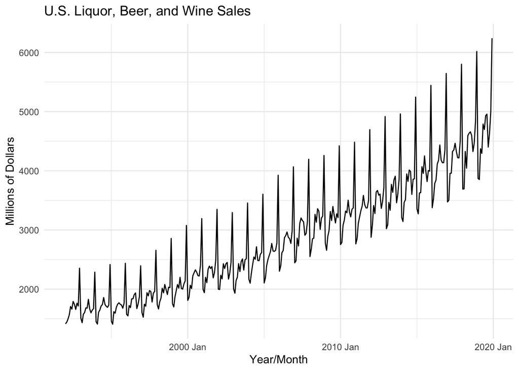

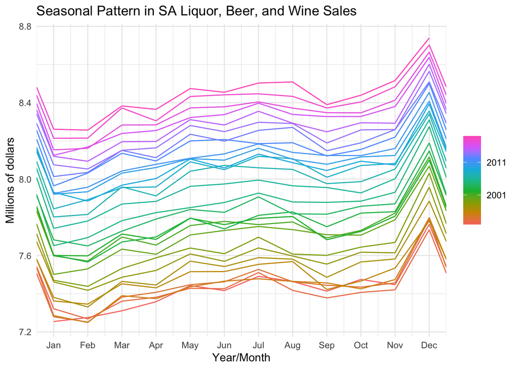

```
Series: sales
Model: ARIMA(1,0,2)(2,1,1)[12] w/ drift
Transformation: log(sales)

Coefficients:
         ar1      ma1     ma2    sar1     sar2     sma1  constant
      0.8948  -0.7374  0.2477  0.3679  -0.2334  -0.8845    0.0036
s.e.  0.0355   0.0697  0.0623  0.0668   0.0665   0.0468    0.0001

sigma^2 estimated as 0.0005469:  log likelihood=752.43
AIC=-1488.85   AICc=-1488.4   BIC=-1458.61
```

```
Series: sales
Model: ETS(A,A,A)
Transformation: log(sales)
  Smoothing parameters:
    alpha = 0.3296099
    beta  = 0.007560263
    gamma = 0.0001765132

  Initial states:
     l[0]         b[0]      s[0]      s[-1]        s[-2]       s[-3]      s[-4]
 7.412219 0.0007608238 0.3263441 0.03153301 -0.004849389 -0.03530501 0.02512163
      s[-5]      s[-6]      s[-7]       s[-8]      s[-9]     s[-10]     s[-11]
 0.05558624 0.01219515 0.02503206 -0.06088935 -0.0607952 -0.1578065 -0.1561667

  sigma^2:  7e-04

      AIC      AICc       BIC
-489.1517 -487.2272 -424.2608
```

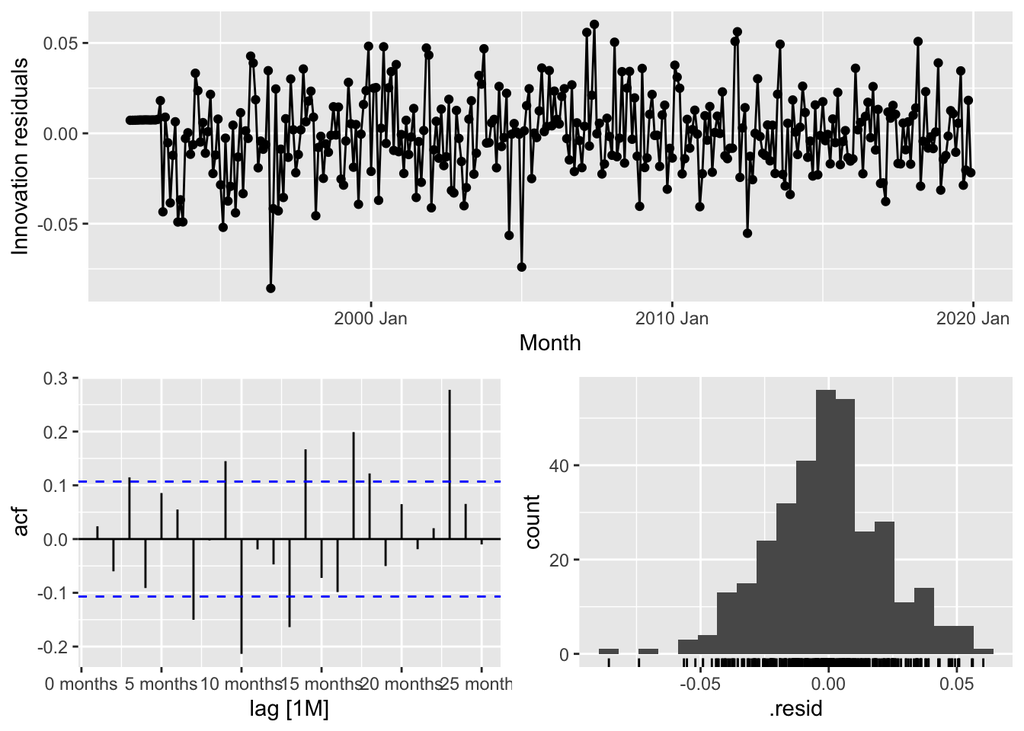

```
# A tibble: 1 × 3
  .model lb_stat lb_pvalue
  <chr>    <dbl>     <dbl>
1 arima     120.         0
```

| .model | .type | RMSE | MAE |
| --- | --- | --- | --- |
| arima | Test | 81.43 | 65.65 |
| ets | Test | 94.35 | 72.31 |
| snaive | Test | 161.26 | 136.63 |

```
    Diebold-Mariano Test

data:  liquor_errs$arimaliquor_errs$ets
DM = -2.9062, Forecast horizon = 1, Loss function power = 2, p-value =
0.004042
alternative hypothesis: two.sided
```

```
    Diebold-Mariano Test

data:  liquor_errs$arimaliquor_errs$snaive
DM = -10.755, Forecast horizon = 1, Loss function power = 2, p-value <
2.2e-16
alternative hypothesis: two.sided
```

2.1 b.)

It has a gradual upward trend from Jan to Dec, then dips after Dec. The trend and dips tend to stay consistent instead of growing or shrinking over time. The highest months are the Summer months and December. The lowest are January through April. The swings do not grow with the series, this suggests that using logs can create a proportional line to show the true patterns.

2.2 a.)

The chosen ARIMA model differences the series by subtracting the previous year’s (same month) value from the current year’s value (same month). The three letters from the ETS model say that the error, trend, and seasonal components are additive, so they don’t scale with the level.

2.3 a.)

215

2.3 b.)

The ARIMA model is most accurate because it has the lowest value for both RMSE and MAE. The two metrics do agree. They are both the lowest out of the rest of the models.

2.4.)

ARIMA vs ETS:

DM statistic: -2.9062, p-value: 0.004042

ARIMA vs snaive:

DM statistic: -10.755, p-value: < 2.2e-16

Because both DM statistics are negative, ARIMA has higher forecast accuracy than both other models. Both p values are below 0.05, showing the results are statistically significant. I would use the ARIMA model if I was a part of the liquor store chain because it has the most accurate forecasts.

## Forecast Combination

| .model | .type | RMSE | MAE |
| --- | --- | --- | --- |
| arima | Test | 81.43 | 65.65 |
| combo | Test | 85.19 | 66.77 |
| ets | Test | 94.35 | 72.31 |
| snaive | Test | 161.26 | 136.63 |

```
[1] 0.8782931
```

3 a.) Combo outperforms both snaive and ETS. Its RMSE and MAE are lower than both the other models named.

3 b.) Because the errors of the ARIMA and ETS model have a strong positive correlation (0.879) and the DM statistics showed ARIMA has higher forecast accuracy, using the combo did not create a better model than the best model (ARIMA).

## VAR vs BVAR

```
[1] 240
```

```
            gdp        cons         inv        emp      infl  unrate     ffr
[1,]  2.2237184  0.95210372   9.5789412  1.2792747 0.1884647 -0.4667 -0.0567
[2,] -0.5398116  1.25352433  -9.7837838  0.2416811 0.3564604  0.1000 -0.2366
[3,]  0.4887350 -0.40052924  -0.2544693 -0.5091283 0.4325238  0.3000 -0.7600
[4,] -1.2914344  0.12942668 -11.7409889 -0.5914079 0.4370749  0.7334 -0.6400
[5,]  0.6727499 -0.03714266   2.5619282 -0.5862248 0.1153772  0.5333 -0.2934
[6,]  1.6836022  1.47721924   6.7723497  0.3046958 0.1983937  0.2000 -0.2700
        gs10
[1,] -0.0966
[2,] -0.2267
[3,] -0.4267
[4,]  0.0534
[5,] -0.1000
[6,]  0.0033
```

```
      gdp      cons       inv       emp      infl    unrate       ffr      gs10
0.5130384 0.4598547 2.4927057 0.1956584 0.2084055 0.1988068 0.3902989 0.3610310
```

```
      gdp      cons       inv       emp      infl    unrate       ffr      gs10
0.5693241 0.5268484 2.5212629 0.2277561 0.2069608 0.2153966 0.4973504 0.3789663
```

| Variable | VAR(1) | VAR(4) | BVAR(4), lambda = 0.3 | BVAR(4), lambda = 0.05 |
| --- | --- | --- | --- | --- |
| gdp | 0.513 | 0.569 | 0.539 | 0.567 |
| cons | 0.460 | 0.527 | 0.486 | 0.495 |
| inv | 2.493 | 2.521 | 2.385 | 2.698 |
| emp | 0.196 | 0.228 | 0.211 | 0.315 |
| infl | 0.208 | 0.207 | 0.197 | 0.330 |
| unrate | 0.199 | 0.215 | 0.203 | 0.216 |
| ffr | 0.390 | 0.497 | 0.414 | 0.358 |
| gs10 | 0.361 | 0.379 | 0.359 | 0.362 |

```
    Diebold-Mariano Test

data:  e_var4e_bvar
DM = 2.1366, Forecast horizon = 1, Loss function power = 2, p-value =
0.03468
alternative hypothesis: two.sided
```

```
    Diebold-Mariano Test

data:  e_var4e_bvar
DM = 1.4529, Forecast horizon = 1, Loss function power = 2, p-value =
0.1489
alternative hypothesis: two.sided
```

4.2.) var1 forecasts better for 7 out of the 8 variables. The smaller model could forecast better because it’s using solely the most recent quarter of lagged data and has to estimate fewer parameters. Adding more quarters can add unnecessary noise and more parameters to predict.

4.3 b.) BVAR with lambda 0.3 barely did better than OLS VAR(4). The reason why it barely did better is because BVAR uses the same data as OLS, but it adds priors through shrinkage. The BVAR uses relatively weak shrinkage (0.3), so it’s close to OLS. VAR(1) outperformed BVAR on the majority of the variables. Making lambda 0.05 actually worsens the model on ⅞ variables. It wouldn’t be a fair estimate because it only performed well for one sample. It should be used on multiple different samples to see the true best model.

4.3 c.) I tested on infl and got 1.4529. However, the p-value is above 0.05 (0.1489), so the results are not statistically significant. My results reinforce my idea that we should apply the models on multiple variables/samples to solidify their performance.

## Factor Model

```
[1] 718 122
```

```
  INDPRO   PAYEMS CPIAUCSL FEDFUNDS
       5        5        6        2
```

```
                            PC1      PC2      PC3      PC4      PC5
Standard deviation     4.258002 2.993839 2.923106 2.597224 2.295261
Proportion of Variance 0.149840 0.074070 0.070620 0.055750 0.043540
Cumulative Proportion  0.149840 0.223910 0.294530 0.350280 0.393820
```

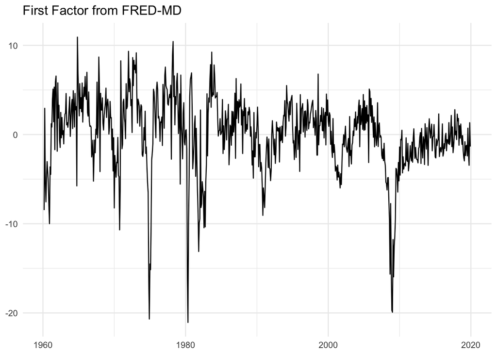

```
   PAYEMS IPMANSICS    USGOOD    INDPRO    MANEMP   IPFPNSS    CUMFNS   DMANEMP
0.8415788 0.8404473 0.8390159 0.8219976 0.8028499 0.7903078 0.7778686 0.7768615
```

```
    CUSR0000SAC DNDGRG3M086SBEA   CUSR0000SA0L2        CPIAUCSL   CUSR0000SA0L5
      0.7468587       0.7391330       0.7279202       0.7198020       0.7020307
       CPITRNSL           PCEPI        CPIULFSL
      0.6806883       0.6795890       0.6570361
```

```
  RMSE_AR   RMSE_FA
0.6168431 0.5887272
```

```
# A tibble: 1 × 7
  series   forecasts RMSE_AR RMSE_FA MAE_AR MAE_FA DM_pvalue
  <chr>        <int>   <dbl>   <dbl>  <dbl>  <dbl>     <dbl>
1 CPIAUCSL       349    2.11    1.89   1.58   1.35  0.000443
```

5.1 c.) INDPRO is turned into growth rates. PAYEMS is turned into growth rates. CPIAUCSL is turned into changes in growth rates. FEDFUNDS is turned into its first difference. They differ because using growth rate wouldn’t work on a set of values that are already percentages.

5.2 a.) 29.45% of the variance is explained in the first three factors.

5.2 b.) I would describe what the first factor is capturing as employment and general manufacturing. I would describe what the second factor is capturing as prices of certain goods and services.

5.3) In forecasting, you are only able to use data that was available prior to the time you were forecasting for. If you use data after that, it isn’t forecasting at that point since you have the actual data you’re trying to forecast.

5.4.) Factors do improve the forecast. The RMSE and MAE are smaller for the factored model than the AR model. The percentage reduced is: 10.43%. The p-value is below 0.05 (0.000443) making the results statistically significant.